# Intervals, counting

Chad Worley

9/15/2021

# Class discussion

- To simplify class, I want to focus on a single tool during lecture.
  - spreadsheets or Rstudio
- I believe it will be easier for everyone if we pick Rstudio.

# Intervals (review)

- A half-bounded interval has 1 boundary.
  - $x<10$

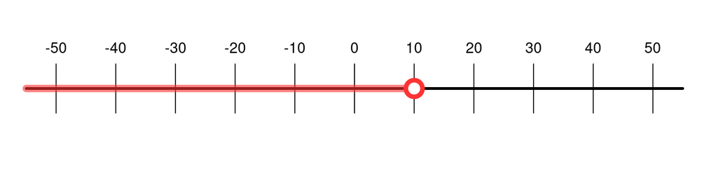

  - $x\ge20$

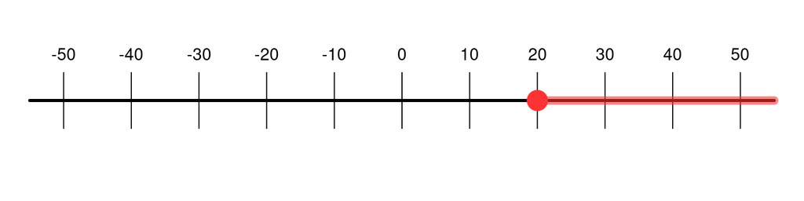

- A bounded interval has 2 boundaries.
  - $-25\le x ~~~\mathtt{AND}~~~ x<40$

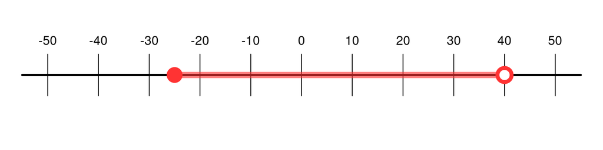

- In stats, we are also interested in two-tail “intervals”.
  - $x<15 ~~~\mathtt{OR}~~~ x>35$

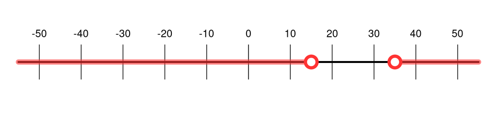

# Bounded intervals have a middle (center) and radius

- In Statistics, we care about distance from center (like in archery, accuracy, error).
- $3.5\le x ~~~\mathtt{AND}~~~ x\le 8.5$

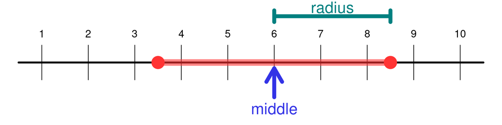

- Let’s say the boundaries are $b_1$ and $b_2$, where $b_2>b_1$.
  $$m = \frac{b_1+b_2}{2}$$
  $$r=\frac{b_2-b_1}{2}$$
- So, in this example…
  $$m = \frac{3.5+8.5}{2} = \frac{12}{2} = 6$$
  $$r = \frac{8.5-3.5}{2} = \frac{5}{2} = 2.5$$

# It is helpful to define intervals using middle and radius.

- $|x-6|\le 2.5$

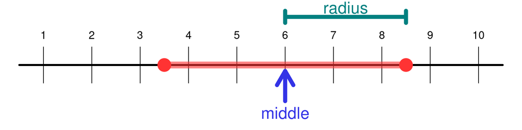

- $|x-6|\ge 2.5$

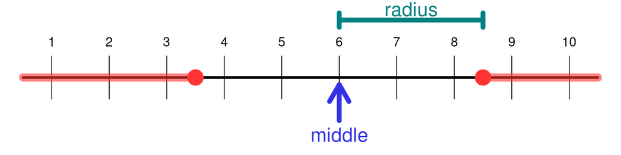

```r
x = 1:10
ineq1 = abs(x-6)<=2.5
ineq2 = abs(x-6)>=2.5
data.frame(x,ineq1,ineq2)
```

```
##     x ineq1 ineq2
## 1   1 FALSE  TRUE
## 2   2 FALSE  TRUE
## 3   3 FALSE  TRUE
## 4   4  TRUE FALSE
## 5   5  TRUE FALSE
## 6   6  TRUE FALSE
## 7   7  TRUE FALSE
## 8   8  TRUE FALSE
## 9   9 FALSE  TRUE
## 10 10 FALSE  TRUE
```

# If you know the middle and radius, you can calculate the bounds

- Doubly bounded interval:
  $$|x-m|<r$$
- Two-tailed interval:
  $$|x-m|>r$$
- Absolute difference is 1-dimensional distance.
  $$|x-m|=\text{distance between }x\text{ and }m$$
- If you know the middle and radius, you can determine the boundaries.
  $$b_{1} = m-r$$
  $$b_{2} = m+r$$

# Counting

- An archer shoots 72 arrows each day. Each arrow scores between 0 and 10 points, depending on its location. The archer records her total score each day.
- 601, 615, 598, 639, 618, 598, 620, 625, 622, 607, 638, 619, 601, 574, 631, 611, 612, 628, 626, 622, 628, 625, 613, 578, 623, 611, 609, 587, 604, 619, 635, 610, 619, 611, 589, 605, 605, 611, 631, 625, 609, 608, 624, 621, 600, 600, 618, 625, 610, 627
- The data can be downloaded.

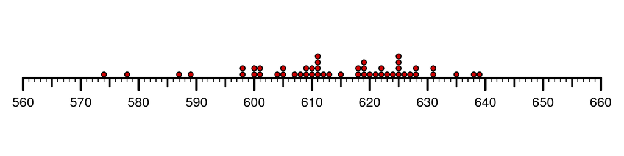

- Determine $n$, the sample size.

```r
x = c(601, 615, 598, 639, 618, 598, 620, 625, 622, 607, 638, 619, 601, 574, 631, 611, 612, 628, 626, 622, 628, 625, 613, 578, 623, 611, 609, 587, 604, 619, 635, 610, 619, 611, 589, 605, 605, 611, 631, 625, 609, 608, 624, 621, 600, 600, 618, 625, 610, 627)
n = length(x)
print(n)
```

```
## [1] 50
```

- Determine $\#(x=600)$

```r
sum(x==600)
```

```
## [1] 2
```

- Determine $\#(x<600)$

```r
sum(x<600)
```

```
## [1] 6
```

- Determine $\#(x>620)$

```r
sum(x>620)
```

```
## [1] 18
```

- Determine $\#(|x-610|<10)$

```r
sum(abs(x-610)<10)
```

```
## [1] 23
```

- Determine $\#(|x-610|>10)$

```r
sum(abs(x-610)>10)
```

```
## [1] 24
```